# Notebook

### Фактический запуск 14.09.2026

Все вычислительные ячейки выполнены. Техническое исполнение не подтверждает научные интерпретации исторического текста. Полный журнал — `legacy-execution.json`.

## Статус воспроизведения исторической редакции

Повторный технический запуск не подтверждает научные выводы старой редакции. Ниже сохранены прежние допущения и интерпретации; их следует сверять с текущими правилами проекта. Дыхательная и ЭКГ-разметка исторических расчётов не получает статус принятой при повторном запуске. Значения толщины 15 и 40 мм — исторические сценарии, а не заново проверенные измерения по КТ. Старые оценки сердечного происхождения сигнала и функций сердца не считаются валидированными.

```
Исторические входы скопированы; запись в исходные метки и параметры исключена.
```

# Полный санированный снимок 30.04 до разделения

> **Статус:** архивный источник происхождения, не активный расчёт и не подтверждённый научный результат.
- Снимок активного файла: `../../30.04_Вычислительное_ядро_двуслойной_модели.ipynb`.
- Коммит состояния до разделения: `de498967b0db226abf65eb1f2a37873d37b44bca`.
- Исторический исходный путь: `Colab Notebooks/05_Анализ_чувствительности_решётки.ipynb`.
- Исходный коммит миграции: `1ac7813654b59861e359cffe3ad40941baeab2d9`.
- Все сохранённые outputs очищены; исходные cell IDs сохранены.

После разделения владельцами становятся `30.04`, `31.01–31.03` и `32.01–32.03`. Этот файл использовать только для проверки полноты переноса.

> **Статус миграции:** это пока действующий объединённый источник, а не окончательно разделённый ноутбук.

> Предусмотренное разделение: `30.04`, `31.01–31.03` и `32.01–32.03`. Полная копия происхождения: `archive/legacy/31.90_Объединённый_анализ_чувствительности.ipynb`. Новые каркасы не считаются реализованными до переноса и сравнения вычислений.

# Анализ чувствительности импеданса и обоснование геометрии электродной сборки

**Модель.** Двуслойная среда: верхний слой — мягкие ткани (удельное сопротивление **ρ₁**, толщина **h**, определяемая кожно-жировым слоем), нижний полупространственный слой — лёгкое (**ρ₂**, меняется при дыхании). Тетраполярная сборка: токовые электроды на ±a, потенциальные на ±b; размер сборки **L = 2a**, форма **β = b/a**.

**Что делает notebook.**

- **§1–2.** Считает чувствительность измеряемого импеданса **Z ко всем параметрам** (ρ₁, ρ₂, h, a, b) — и абсолютную (производные), и относительную (эластичности), с интерпретацией.
- **§3.** Объясняет, **откуда берётся усиление ошибки** «X% неточности h → Y% ошибки ρ₂», при каких условиях, и **как оно зависит от геометрии** (размер L vs отношение b/a vs толщина h). Здесь же — что такое **FoM (сигнал/помеха)**.
- **§4–6.** Прикладные задачи: сигнал дыхания, минимальный размер сборки Lₘᵢₙ(h), обоснование набора баз (матрица Фишера).

Все формулы выведены в `04_Чувствительность_и_дизайн_решётки.md`; здесь они реализованы и прокомментированы.

## §0. Методика анализа чувствительности и словарь терминов

Раздел определяет решаемую задачу, метод, обоснование выбора и все термины, используемые далее. Термины не употребляются в последующих разделах раньше, чем определены здесь.

### Решаемая задача

Требуется обосновать геометрию электродных сборок для восстановления удельного сопротивления лёгкого ρ₂ и количественно оценить, как погрешности мешающих параметров (толщины слоя мягких тканей h и удельного сопротивления мягких тканей ρ₁) переносятся на оценку ρ₂. На этой основе определяются минимальный размер сборки, оптимальная форма сборки и оптимальный набор размеров.

### Модель и метод

Прямая задача — двуслойная полубесконечная модель (§0 ноутбука 09; вывод — 03): слой мягких тканей толщины h с удельным сопротивлением ρ₁ над лёгким-полупространством с сопротивлением ρ₂; измерение тетраполярным методом электродной сборкой, форма сборки β = b/a. Метод — аналитические производные импеданса по параметрам (сверяются с численными), безразмерные чувствительности (эластичности) и матрица Фишера. Полный вывод — в 04.

### Словарь терминов

- **Электродная сборка** — совокупность четырёх электродов для одного тетраполярного измерения; размер L = 2a (токовая база), форма β = b/a (отношение потенциальной полубазы к токовой).
- **Рабочая точка** — набор значений (L, β, h, ρ₁, ρ₂), в котором вычисляются локальные чувствительности.
- **Эластичность** (относительная чувствительность) — безразмерная величина, показывающая, на сколько процентов изменится импеданс при изменении параметра на один процент:

$$S_p=\frac{\partial \ln Z}{\partial \ln p}=\frac{p}{Z}\,\frac{\partial Z}{\partial p} \tag{5.1}$$

где S_p — эластичность импеданса по параметру p, безразмерная; Z — импеданс, Ом; p — параметр (ρ₁, ρ₂ или h). Эластичность по ρ₂ есть **полезный сигнал** (зависимость от дыхания), по h — **главная помеха**.

- **Показатель качества сигнал/помеха** (FoM, figure of merit — показатель качества) — отношение полезного сигнала к главной помехе:

$$\mathrm{FoM}=\frac{S_{\rho_2}}{|S_h|} \tag{5.2}$$

где FoM — показатель качества, безразмерный. Чем он больше, тем слабее погрешность толщины влияет на оценку ρ₂.

- **Коэффициент усиления ошибки** — во сколько раз относительная погрешность толщины переносится в относительную погрешность ρ₂:

$$K_h=-\frac{S_h}{S_{\rho_2}}=\frac{1}{\mathrm{FoM}} \tag{5.3}$$

где K_h — коэффициент усиления ошибки, безразмерный.

- **Матрица Фишера** — мера информации набора измерений о параметрах; по ней вычисляется нижняя граница ковариации оценок:

$$\mathbf M=J^{\top}\boldsymbol\Sigma^{-1}J,\qquad \mathrm{Cov}(\hat{\boldsymbol\theta})\succeq \mathbf M^{-1} \tag{5.4}$$

где M — матрица Фишера; J — матрица производных импеданса по параметрам (якобиан); Σ — ковариация шума измерений. Из неё: **стандартное отклонение оценки** std(ρ₂) = √(M⁻¹)_{ρ₂ρ₂}; **корреляция помехи и сигнала** corr(h, ρ₂); **число обусловленности** cond(M).

- **c-оптимальность** — выбор геометрии, минимизирующий дисперсию целевой оценки ρ₂: min (M⁻¹)_{ρ₂ρ₂}.
- **Минимальный размер сборки** L_min(h) — наименьший размер, при котором дыхание ещё различимо при толщине h; растёт линейно с толщиной, L_min ∝ h.
- **Индексы Соболя** — доли дисперсии импеданса, вносимые каждым параметром во всём диапазоне значений (глобальная чувствительность, в отличие от локальной эластичности в рабочей точке).
- **Теорема взаимности** — свойство тетраполярного измерения: перестановка ролей токовой и потенциальной пар при фиксированных позициях электродов не меняет импеданс; служит проверкой корректности модели.

### Как оценивать результаты

Геометрия тем лучше для восстановления ρ₂, чем больше показатель качества (5.2) и меньше стандартное отклонение оценки std(ρ₂) и число обусловленности матрицы Фишера. Набор размеров должен покрывать минимальный размер сборки для всего ожидаемого диапазона толщины.

**Входные данные.** Рабочая точка анализа: размер сборки L = 140 мм, форма β = b/a = 0.5, толщина слоя мягких тканей h = 20 мм, удельные сопротивления ρ₁ = 5, ρ₂ = 20 Ом·м.

**Допущения.** Рабочая точка выбрана как типичная для эксперимента; локальные чувствительности зависят от неё, поэтому она фиксируется явно и указывается при каждом результате.

```
Конфигурация задана.
Рабочая точка: L=140 мм, b/a=0.50, h=20 мм, rho1=5.0, rho2=20.0 Ом·м
```

**Анализ результатов.** Ячейка задаёт конфигурацию и выводит рабочую точку.

**Результаты и умозаключения.** Рабочая точка — общий вход для всех разделов, вычисляющих локальные чувствительности.

## §1. Прямая модель и её производные

Определение импеданса двуслойной модели (5.1 — см. §0) и его аналитических производных по всем параметрам; производные нужны для эластичностей и матрицы Фишера.

**Входные данные.** Параметры прямой задачи и рабочая точка из §0.

**Допущения.** Импеданс двуслойной модели и его производные по ρ₁, ρ₂, h, a, b заданы в замкнутой форме (вывод — 04); это избавляет от конечных разностей и даёт точные эластичности (5.1).

```
Модель и производные определены.
```

**Анализ результатов.** Функции модели и производных определены.

**Результаты и умозаключения.** Определённые производные — вход для §1.1 (самоконтроль), §2 (эластичности) и §6 (матрица Фишера).

### §1.1. Самоконтроль кода: производные и инварианты

**Входные данные.** Аналитические производные из §1 и их численные оценки конечными разностями в рабочей точке.

**Допущения.** Чтобы убедиться в корректности аналитических производных, они сравниваются с численными; дополнительно проверяются инварианты однородности импеданса по сопротивлениям и по геометрии.

```
производная | аналитически   | численно       | отн.расхождение
  ∂Z/∂ρ2   | +9.057692e-01 | +9.057692e-01 | 1.3e-08
  ∂Z/∂ρ1   | +7.465694e+00 | +7.465694e+00 | 6.6e-09
  ∂Z/∂h    | -1.504109e+03 | -1.504109e+03 | 8.2e-10
  ∂Z/∂a    | -1.456134e+03 | -1.456134e+03 | 1.3e-11
  ∂Z/∂b    | +2.187649e+03 | +2.187649e+03 | 6.0e-13

Инвариант 1: (ρ1·Zρ1+ρ2·Zρ2)/Z = 1.000000  (ожидаем +1)
Инвариант 2: (a·Za+b·Zb+h·Zh)/Z = -1.000000  (ожидаем −1)
```

**Анализ результатов.** Аналитические и численные производные совпадают с относительным расхождением 10⁻⁸…10⁻¹³. Инвариант по сопротивлениям (ρ₁·∂Z/∂ρ₁ + ρ₂·∂Z/∂ρ₂)/Z = +1 и инвариант по геометрии (a·∂Z/∂a + b·∂Z/∂b + h·∂Z/∂h)/Z = −1 выполнены точно.

**Результаты и умозаключения.** Производные подтверждены; их можно использовать в эластичностях и матрице Фишера без опасения ошибок дифференцирования.

### §1.2. Самоконтроль: теорема взаимности

**Входные данные.** Импеданс, вычисленный при прямом и переставленном назначении ролей токовой и потенциальной пар электродов.

**Допущения.** Теорема взаимности (§0) требует равенства импеданса при перестановке ролей пар; это проверка корректности модели. Отдельно показывается, что подстановка b > a в замкнутую формулу — не взаимность, а выход за область применимости (формула выведена для a > b).

```
Взаимность (перестановка ролей пар при фиксированных позициях):
  ток@±a, потенциал@±b :  Z = 55.443852 Ом
  ток@±b, потенциал@±a :  Z = 55.443852 Ом
  совпадают: True  -> взаимность выполнена
  Z_model(a,b)         = 55.443852 Ом  (та же величина)

Литеральная подстановка b>a в замкнутую формулу — НЕ взаимность, а выход за область применимости:
  Z_model(a=b_inner, b=a_outer) = -35.5018 Ом  (неверно: формула выведена для a>b)
```

**Анализ результатов.** При перестановке ролей пар импеданс совпадает (55.44 Ом в обоих случаях) — взаимность выполнена. Подстановка b > a даёт отрицательный импеданс (−35.5 Ом), что подтверждает: формула применима только при a > b.

**Результаты и умозаключения.** Модель корректна в области a > b; вне её результаты недостоверны — это ограничение учитывается при переборе форм β в §8.

## §2. Чувствительность импеданса ко всем параметрам в рабочей точке

**Входные данные.** Производные импеданса и рабочая точка из §0.

**Допущения.** Чтобы сопоставить влияние всех параметров в единой безразмерной шкале, вычисляются эластичности (5.1) по ρ₁, ρ₂, h, a, b.

```
параметр |   ∂Z/∂p      | эластичность S_p | трактовка: +1%% параметра -> ... %% Z
--------------------------------------------------------------------------------------------
  ρ1     | +7.4657e+00 |   +0.673       |  +0.67%   (сопр. мягких тканей)
  ρ2     | +9.0577e-01 |   +0.327       |  +0.33%   (сопр. лёгкого = ДЫХАНИЕ (сигнал))
  h      | -1.5041e+03 |   -0.543       |  -0.54%   (толщина жира = ПОМЕХА)
  a      | -1.4561e+03 |   -1.838       |  -1.84%   (токовая полубаза (геометрия))
  b      | +2.1876e+03 |   +1.381       |  +1.38%   (потенц. полубаза (геометрия))
```

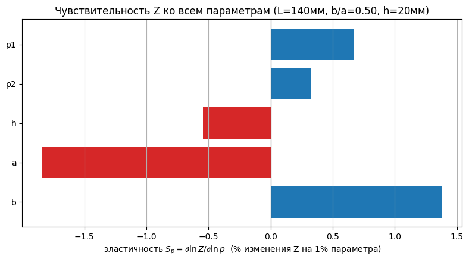

**Анализ результатов.** В рабочей точке эластичность по ρ₂ (сигнал дыхания) равна +0.33, по ρ₁ +0.67, по h (помеха) −0.54; геометрические эластичности по a и b по модулю больше единицы (−1.84 и +1.38), то есть импеданс наиболее чувствителен к точности установки электродов.

**Результаты и умозаключения.** Полезный сигнал (эластичность по ρ₂) меньше помехи (эластичности по h и ρ₁); отсюда следует необходимость дизайна геометрии, повышающего сигнал относительно помехи (§3, §6, §8). Высокая чувствительность к a, b задаёт требования к точности установки сборок.

### §2.1. Как читать результат

- **ρ₁ и ρ₂** — физика среды. Их эластичности в сумме дают 1 ($S_{\rho_1}+S_{\rho_2}=1$). В рабочей точке $S_{\rho_1}\approx0.67$, $S_{\rho_2}\approx0.33$ — то есть **мягкие ткани влияют на Z сильнее, чем лёгкое**: дыхательный сигнал ($\rho_2$) — лишь треть отклика. Это и есть корень проблемы: полезный сигнал слабее фона.
- **h** — отрицательная эластичность ($\approx-0.54$): толще жир ⟹ меньше Z. По модулю **сравнима с $S_{\rho_1}$ и больше $S_{\rho_2}$** — поэтому неопределённость толщины так опасна (§3).
- **a, b** — самые большие по модулю эластичности ($S_a\approx-1.8$, $S_b\approx+1.4$): Z очень чувствителен к **точности установки электродов**. Сдвиг электрода на 1 % уже меняет Z на 1–2 %. Вывод: позиционирование сборки должно быть точным (или учитываться в модели).

## §3. Перенос погрешности толщины на ρ₂ и показатель качества

**Входные данные.** Эластичности по ρ₂ и h в рабочей точке из §2.

**Допущения.** Чтобы выразить, как погрешность толщины переносится на ρ₂, вычисляются показатель качества (5.2) и коэффициент усиления ошибки (5.3).

```
УСЛОВИЯ (рабочая точка): L=140 мм, b/a=0.50, h=20 мм, rho1=5.0, rho2=20.0
----------------------------------------------------------------
  сигнал  S_rho2 = +0.327
  помеха  S_h    = -0.543
  FoM = S_rho2/|S_h| = 0.602
  усиление ошибки K_h = -S_h/S_rho2 = 1.66
  =>  10% ошибки в h  ->  17% ошибки в rho2
  =>   5% ошибки в h  ->  8% ошибки в rho2

Именно отсюда «10%% -> 17%%»: это значение K_h ИМЕННО в этой точке и зависит от геометрии (см. ниже).
```

**Анализ результатов.** В рабочей точке показатель качества FoM = 0.60, коэффициент усиления ошибки K_h = 1.66; следовательно, 10 % погрешности толщины дают около 17 % погрешности ρ₂.

**Результаты и умозаключения.** Соотношение «10 % → 17 %» — прямое следствие геометрии рабочей точки. Так как K_h > 1, толщину нужно знать точнее, чем требуемая точность ρ₂; это обосновывает измерение толщины по томографии (§0 ноутбука 09).

### §3.1. От чего зависит усиление ошибки: размер сборки, форма и толщина

**Входные данные.** Коэффициент усиления ошибки (5.3) как функция размера сборки L, формы β и толщины h.

**Допущения.** Чтобы понять, чем управляется усиление ошибки, K_h строится в зависимости от каждого из трёх факторов по отдельности.

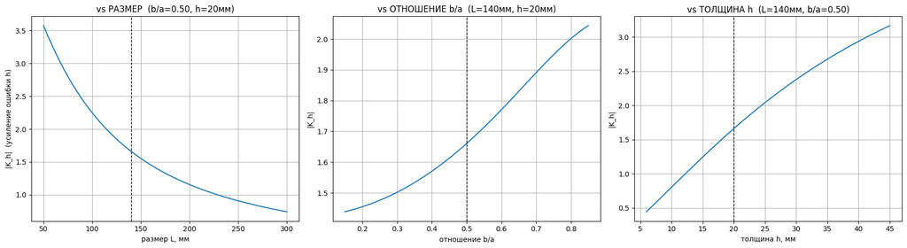

```
Размах |K_h|:  по L: 0.74..3.58 | по b/a: 1.44..2.04 | по h: 0.44..3.17
```

**Анализ результатов.** Размах |K_h|: по размеру сборки 0.74…3.58, по форме 1.44…2.04, по толщине 0.44…3.17. Наибольшее влияние оказывают размер сборки и толщина.

**Результаты и умозаключения.** Усиление ошибки уменьшается с ростом размера сборки и уменьшением толщины; это направление и используется при оптимизации геометрии (§8).

**Входные данные.** Коэффициент усиления ошибки (5.3) на сетке размеров сборки L и форм β при фиксированной толщине h = 20 мм.

**Допущения.** Чтобы найти лучшую комбинацию размера и формы, строится карта |K_h|(L, β).

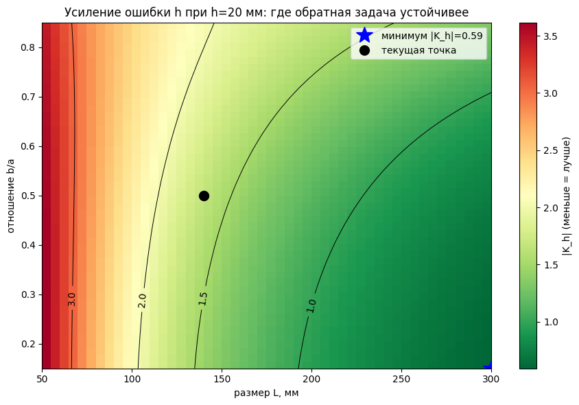

```
Лучшая комбинация при h=20мм: L=300 мм, b/a=0.15 -> |K_h|=0.59
```

**Анализ результатов.** Минимум |K_h| = 0.59 достигается при большом размере сборки (L = 300 мм) и малой форме (β = 0.15). Малое β повышает сигнал, но снижает измеряемое напряжение; крупный размер ограничен плоскостностью модели.

**Результаты и умозаключения.** Направление к меньшему усилению ошибки — крупные размеры и малые β; практический выбор ограничен верхней границей размера (плоскостность) и минимально допустимым напряжением, что учитывается в §8.

### §3.2. Выводы по усилению ошибки

- **Сильнее всего — от размера L.** Увеличение базы резко снижает $|K_h|$ (крупная сборка глубже «видит» лёгкое ⟹ дыхательный сигнал $S_{\rho_2}$ растёт ⟹ влияние неопределённости $h$ относительно слабеет). Это **главный рычаг** борьбы с неопределённостью жирового слоя.
- **Слабее — от отношения b/a.** Меньшее $b/a$ немного улучшает $|K_h|$, но эффект вторичен по сравнению с размером.
- **Толщина h — это сама помеха, а не рычаг.** Чем толще кожно-жировой слой, тем больше $|K_h|$: у «полных» пациентов та же относительная неопределённость $h$ сильнее портит $\rho_2$. Поэтому для них особенно важны крупные базы и/или **независимое измерение $h$** (УЗИ/МРТ).
- **Лучшая геометрия:** максимально возможный $L$ при умеренно малом $b/a$ (см. синюю звезду на карте).

## §4. Дыхательный сигнал $Z(\rho_2)$ в зависимости от размера сборки и толщины

**Входные данные.** Дыхательный размах импеданса как функция размера сборки L и толщины h (при заданном изменении ρ₂ между вдохом и выдохом).

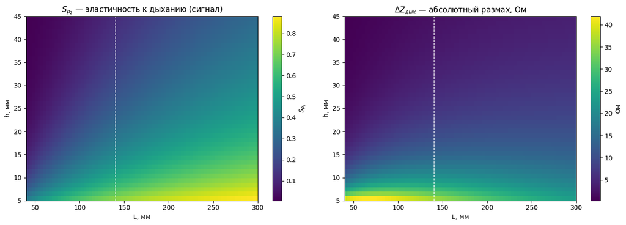

```
Белый пунктир — текущая макс. база 140 мм. Сигнал растёт вправо (база) и вниз (тоньше жир).
```

**Анализ результатов.** Сигнал растёт при увеличении размера сборки и уменьшении толщины; текущая максимальная база 140 мм отмечена на карте.

**Результаты и умозаключения.** Крупные сборки информативнее для ρ₂ по относительному сигналу; это согласуется с выводом §3 и обосновывает расширение набора размеров вверх (§6, §8).

## §5. Минимальный размер сборки $L_{\min}(h)$

**Входные данные.** Модель, эластичности и три критерия минимального размера сборки (по измеримости сигнала, по глубине проникновения, по идентифицируемости).

**Допущения.** Чтобы определить наименьший пригодный размер сборки при данной толщине, вычисляется L_min(h) по трём критериям; основной — по идентифицируемости (порог показателя качества).

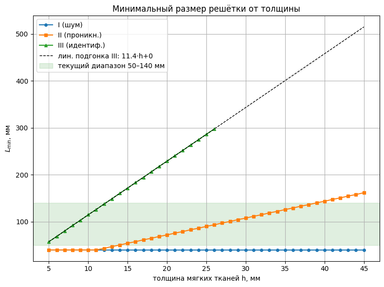

```
Наклон Lmin(III) ≈ 11.4 -> подтверждает линейный закон Lmin ∝ h.
Где кривая выходит выше зелёной зоны — текущих баз не хватает (толстый жировой слой).
```

**Анализ результатов.** Наклон зависимости L_min от толщины около 11.4, что подтверждает линейный закон L_min ∝ h. При большой толщине текущих размеров сборок не хватает.

**Результаты и умозаключения.** Диапазон размеров должен покрывать L_min(h) для всего ожидаемого разброса толщины; иначе для толстого слоя мягких тканей сигнал недостаточен — это вход для оптимизации набора (§8).

## §6. Обоснование набора размеров сборок — матрица Фишера

**Входные данные.** Матрица Фишера (5.4) для нескольких наборов размеров сборок при равном шуме измерений.

**Допущения.** Чтобы сравнить наборы размеров, для каждого вычисляются стандартное отклонение оценки ρ₂, корреляция толщины и ρ₂, число обусловленности матрицы Фишера.

Масштаб шума σ, входящий в матрицу Фишера, принимается равным фактическому расхождению модели и данных, а не разрешению измерителя. Разрешение измерителя (0.02 Ом) на два-три порядка меньше среднеквадратичного остатка совместной подгонки (7.40 и 15.10 Ом, 09 §3), поэтому подстановка разрешения давала бы стандартное отклонение оценки, заниженное во столько же раз. Стандартное отклонение оценки пропорционально σ, поэтому сравнение наборов размеров между собой от этого выбора не зависит, а абсолютные значения зависят прямо.

Принятое σ является эффективным: остаток подгонки не сводится к некоррелированному шуму измерения, поскольку содержит воспроизводимую систематику, связанную с размером сборки, величиной 3.9–4.8 % (09 §2.2) и ошибку самой двуслойной модели. Для коррелированной составляющей граница Крамера–Рао неприменима, поэтому получаемое стандартное отклонение следует читать как оценку снизу для достижимой неопределённости и как оценку сверху для достижимой точности.

```
набор баз                      | std(rho2) | corr(h,rho2) | cond(M)
------------------------------------------------------------------------------
текущий 50–140 (шаг 10)        |   39.059  |     0.97     | 3.9e+08
расширенный 50–200 (шаг 15)    |   18.342  |     0.94     | 8.2e+07
расширенный 50–300 (шаг 25)    |   10.680  |     0.89     | 2.1e+07
только крупные 100–200         |   53.957  |     0.96     | 4.0e+08

Вывод: расширение баз вверх снижает std(rho2) и корреляцию h↔rho2 (разрывает вырождение).
std(rho2) пропорционально sigma; здесь sigma=10.00 Ом — фактическая невязка, не разрешение прибора.
```

**Анализ результатов.** При масштабе невязки σ = 10 Ом текущий набор 50–140 мм даёт стандартное отклонение оценки ρ₂, равное 39.1 Ом·м, корреляцию толщины и ρ₂ 0.97 и число обусловленности 3.9·10⁸. Расширение вверх до 200 и 300 мм снижает стандартное отклонение до 18.3 и 10.7 Ом·м и уменьшает корреляцию до 0.94 и 0.89. Набор только из крупных сборок 100–200 мм даёт 54.0 Ом·м, то есть хуже текущего: без мелких сборок ρ₁ и h не закрепляются, и вырождение усиливается.

Абсолютные значения следует читать в сопоставлении с самим ρ₂ (порядка 20 Ом·м): стандартное отклонение 39.1 Ом·м означает, что при текущем наборе и фактическом уровне расхождения модели с данными ρ₂ не определяется вовсе. Это согласуется с прямым наблюдением обратной задачи (09 §3.1), где профиль невязки по ρ₂ не имеет минимума внутри допустимого диапазона.

**Результаты и умозаключения.** Расширение набора вверх снижает неопределённость ρ₂ и разрывает вырождение между толщиной и ρ₂; это обоснование расширения диапазона размеров (§8), ограниченного сверху плоскостностью модели. Отношение стандартных отклонений между наборами не зависит от принятого σ, поэтому вывод о полезности расширения устойчив; абсолютные значения пропорциональны σ и потому улучшатся вместе со снижением расхождения модели и данных — в частности, после устранения систематики отдельных сборок (09 §2.2.1).

**Входные данные.** Стандартное отклонение оценки ρ₂ по матрице Фишера (5.4) для наборов размеров при разной толщине h.

**Допущения.** Чтобы проверить пригодность набора во всём диапазоне толщины, стандартное отклонение оценки ρ₂ вычисляется как функция толщины.

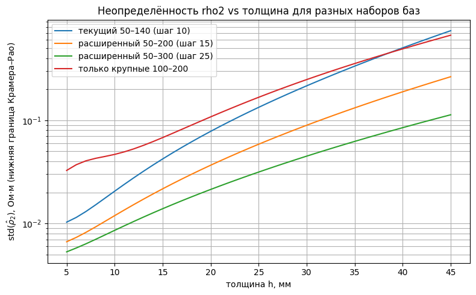

```
Для больших h текущий набор даёт резко худшую оценку — нужны крупные базы.
```

**Анализ результатов.** При большой толщине текущий набор даёт резко худшую оценку ρ₂; нужны крупные размеры сборок.

**Результаты и умозаключения.** Робастный по толщине набор должен включать крупные размеры; это учитывается при оптимизации (§8) и объясняет неопределимость ρ₂ у толстого испытуемого (09 §3.1).

## §7. Глобальная чувствительность — индексы Соболя (опционально)

**Входные данные.** Модель и физиологические диапазоны параметров для выборки Соболя (при установленной библиотеке SALib).

**Допущения.** Чтобы оценить вклад каждого параметра во всём диапазоне значений, а не только в рабочей точке, вычисляются индексы Соболя (§0).

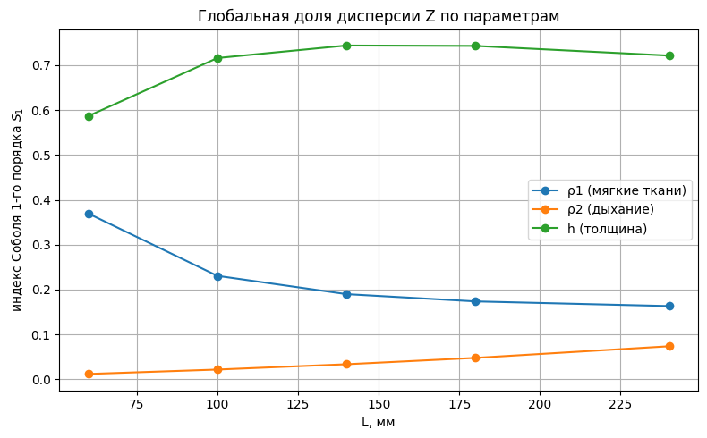

```
Доля дисперсии от ρ2 (дыхание) растёт с базой; h остаётся весомой помехой.
```

**Анализ результатов.** Доля дисперсии импеданса, вносимая ρ₂ (дыханием), растёт с размером сборки, тогда как толщина остаётся весомой помехой во всём диапазоне.

**Результаты и умозаключения.** Глобальный анализ подтверждает локальный вывод §2–§3: крупные размеры информативнее для ρ₂, толщина — главная помеха.

## §8. Оптимизация геометрии сборки $(L,\beta)$ на калиброванных данными параметрах

**Входные данные.** Калиброванная данными рабочая точка (ρ₁, ρ₂, h) из 09 и 10; ограничения на размер сборки (нижнее — минимальный размер, верхнее — плоскостность модели, задано заглушкой L_max = 200 мм); критерий c-оптимальности (§0).

**Допущения.** Чтобы перевести дизайн из модельного в расчёт на реальных параметрах, оптимизация ведётся по c-оптимальности (минимум дисперсии ρ₂) в допустимом диапазоне размеров. Верхняя граница L_max пока задана заглушкой 200 мм; её строгое значение (плоскостность) требует расчёта по томографии.

```
c-оптимальность = min std(ρ2). L набора ∈ [40, 200 мм]: мелкие базы закрепляют ρ1,
крупные несут ρ2; верх ограничен плоскостностью Lmax из КТ (§8.3).

  Георгий (h=40)   std(ρ2) текущего набора 50–140 = 112.250 Ом·м
  Ник (h=15)       std(ρ2) текущего набора 50–140 = 14.065 Ом·м
```

**Анализ результатов.** Для текущего набора 50–140 мм при фактическом масштабе невязки по каждому испытуемому (7.40 Ом у Ника, 15.10 Ом у Георгия) стандартное отклонение оценки ρ₂ равно 112.3 Ом·м у Георгия (h = 40 мм) и 14.07 Ом·м у Ника (h = 15 мм).

Эти значения количественно воспроизводят результат обратной задачи, полученный независимо. У Ника ρ₂ восстановлена как 17.12 Ом·м при стандартном отклонении 14.07 Ом·м, то есть определена, но с неопределённостью порядка самой величины — что соответствует характеристике «оценка шаткая» в 09 §3. У Георгия стандартное отклонение 112.3 Ом·м при ожидаемом ρ₂ около 18.6 Ом·м превышает величину в шесть раз, что соответствует выходу оценки на верхний предел допустимого диапазона в 09 §3.1. Совпадение предсказания матрицы Фишера с наблюдаемым поведением обратной задачи подтверждает, что причина неопределимости — обусловленность, а не дефект решателя.

**Результаты и умозаключения.** Установлены рабочая точка и ограничения оптимизации; при большой толщине текущий набор недостаточен, что мотивирует расширение диапазона размеров (§8.3). Поскольку принятое σ включает воспроизводимую систематику отдельных сборок (09 §2.2), приведённые стандартные отклонения являются оценками сверху для достижимой неопределённости: калибровка сборок способна снизить σ примерно втрое и во столько же — стандартное отклонение оценки ρ₂.

**Входные данные.** Эластичности как функция формы β = b/a при фиксированном размере сборки (модельный расчёт; все измерения сделаны при β = 0.5).

**Допущения.** Чтобы оценить влияние формы, стандартное отклонение оценки ρ₂ вычисляется в зависимости от β. Так как измерения выполнены только при β = 0.5, результат по β — модельная рекомендация, а не вывод из данных.

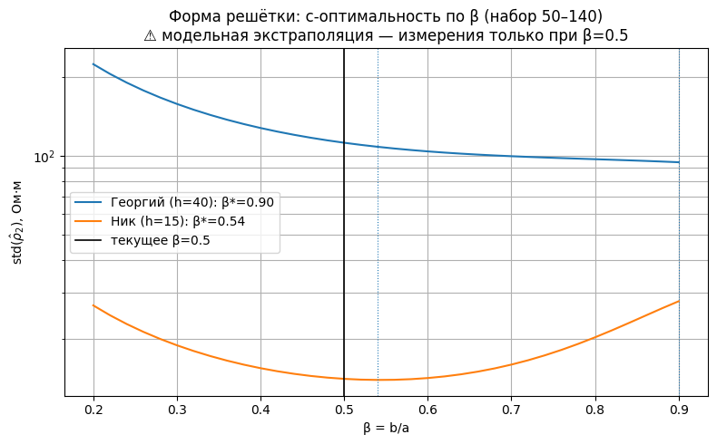

**Результаты и умозаключения.** Рекомендация по β — для будущих сборок; подтверждение требует измерений при других β.

**Входные данные.** Калиброванная рабочая точка, ограничения на размер сборки и критерий c-оптимальности; оптимизация ведётся по набору из десяти размеров в диапазоне 40–200 мм.

**Допущения.** Чтобы найти оптимальный набор размеров под каждую толщину, минимизируется стандартное отклонение оценки ρ₂ при ограничениях на диапазон размеров.

```
субъект          | std тек.50–140 | оптим. набор {L_k}, мм                 | std опт.
--------------------------------------------------------------------------------------------
Георгий (h=40)   |    112.250      | [40, 70, 80, 90, 100, 110, 120, 180, 190, 200] | 34.649
Ник (h=15)       |    14.065      | [40, 60, 70, 80, 90, 120, 170, 180, 190, 200] | 5.674
```

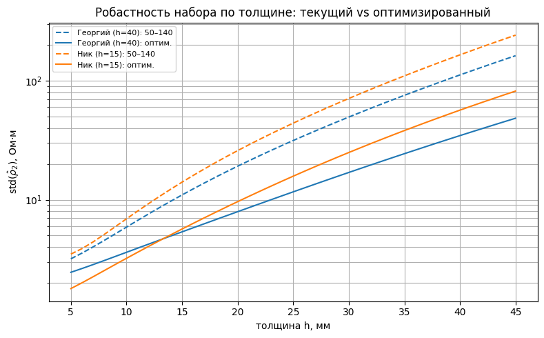

**Анализ результатов.** Оптимальный набор смещён к крупным размерам и снижает стандартное отклонение оценки ρ₂: у Георгия со 112.3 до 34.6 Ом·м, у Ника с 14.07 до 5.67 Ом·м, то есть примерно втрое у обоих. Отношение не зависит от принятого масштаба невязки, поскольку стандартное отклонение пропорционально σ.

Даже после оптимизации набора у Георгия стандартное отклонение (34.6 Ом·м) остаётся вдвое больше самой оцениваемой величины (около 18.6 Ом·м). Следовательно, при толщине мягких тканей 40 мм одним лишь выбором размеров сборок задача не решается: требуется либо снижение расхождения модели с данными, либо иная измерительная схема.

**Результаты и умозаключения.** Расширение набора вверх (до границы плоскостности) втрое снижает неопределённость ρ₂; конкретная верхняя граница требует расчёта плоскостности по томографии (открытый вопрос, 06 §2.5). Для толстых мягких тканей расширения набора недостаточно, и первоочередным становится снижение σ: устранение систематики отдельных сборок калибровкой (09 §2.2.1) даёт выигрыш того же порядка, что и оптимизация геометрии, и не требует новых сборок.

### §8.4. Выводы

- При фиксированном $\beta=0.5$ расширение набора вверх (к $L_{\max}$ из КТ) снижает $\mathrm{std}(\hat\rho_2)$, особенно для толстых тканей — крупные базы несут $\rho_2$ (ср. §6).
- Оптимум по $\beta$ — **модельное предсказание** для будущих сборок; подтверждается только измерениями при других $\beta$.
- Ключевое ограничение — $L_{\max}(h,\text{анатомия})$: без него оптимизатор бесконтрольно растит $L$. Замените заглушку `L_MAX_MM` границей плоскостности из КТ/МКЭ (§2.5, §3.3 документа перекрёстной проверки).
- Рабочую точку $(\rho_1,\rho_2,h)$ и $\sigma_Z$ обновляйте из `09_Статическая_оценка_параметров.ipynb`.